# Risk Factor Analysis

## Outcome Variable

**Outcome Variable:** ever_stunted

## Predictor Variables

**Intervention Variable:** parity

**Adjustment Set:**

unadjusted

## Stratifying Variables

The analysis was stratified on these variable(s):

- agecat
- studyid

The following strata were considered:

- agecat: 12 months, studyid: ki1000304b-SAS-FoodSuppl
- agecat: 12 months, studyid: ki1017093b-PROVIDE
- agecat: 12 months, studyid: ki1066203-TanzaniaChild2
- agecat: 12 months, studyid: ki1101329-Keneba
- agecat: 12 months, studyid: ki1113344-GMS-Nepal
- agecat: 12 months, studyid: ki1126311-ZVITAMBO
- agecat: 12 months, studyid: ki1135781-COHORTS
- agecat: 18 months, studyid: ki1000304b-SAS-FoodSuppl
- agecat: 18 months, studyid: ki1017093b-PROVIDE
- agecat: 18 months, studyid: ki1066203-TanzaniaChild2
- agecat: 18 months, studyid: ki1101329-Keneba
- agecat: 18 months, studyid: ki1113344-GMS-Nepal
- agecat: 18 months, studyid: ki1126311-ZVITAMBO
- agecat: 18 months, studyid: ki1135781-COHORTS
- agecat: 24 months, studyid: ki1000304b-SAS-FoodSuppl
- agecat: 24 months, studyid: ki1017093b-PROVIDE
- agecat: 24 months, studyid: ki1066203-TanzaniaChild2
- agecat: 24 months, studyid: ki1101329-Keneba
- agecat: 24 months, studyid: ki1113344-GMS-Nepal
- agecat: 24 months, studyid: ki1126311-ZVITAMBO
- agecat: 24 months, studyid: ki1135781-COHORTS
- agecat: 3 months, studyid: ki1017093b-PROVIDE
- agecat: 3 months, studyid: ki1066203-TanzaniaChild2
- agecat: 3 months, studyid: ki1101329-Keneba
- agecat: 3 months, studyid: ki1113344-GMS-Nepal
- agecat: 3 months, studyid: ki1126311-ZVITAMBO
- agecat: 3 months, studyid: ki1135781-COHORTS
- agecat: 6 months, studyid: ki1000304b-SAS-FoodSuppl
- agecat: 6 months, studyid: ki1017093b-PROVIDE
- agecat: 6 months, studyid: ki1066203-TanzaniaChild2
- agecat: 6 months, studyid: ki1101329-Keneba
- agecat: 6 months, studyid: ki1113344-GMS-Nepal
- agecat: 6 months, studyid: ki1126311-ZVITAMBO
- agecat: 6 months, studyid: ki1135781-COHORTS

### Dropped Strata

Some strata were dropped due to rare outcomes:

- agecat: 12 months, studyid: ki1000304b-SAS-FoodSuppl
- agecat: 18 months, studyid: ki1000304b-SAS-FoodSuppl
- agecat: 24 months, studyid: ki1000304b-SAS-FoodSuppl

## Methods Detail

We’re interested in the causal parameters $E[Y_a]$ for all values of $a \in \mathcal{A}$. These parameters represent the mean outcome if, possibly contrary to fact, we intervened to set all units to have $A=a$. Under the randomization and positivity assumptions, these are identified by the statistical parameters $\psi_a=E_W[E_{Y|A,W}(Y|A=a,W)]$. In addition, we’re interested in the mean of $Y$, $E[Y]$ under no intervention (the observed mean). We will estimate these parameters by using SuperLearner to fit the relevant likelihood factors – $E_{Y|A,W}(Y|A=a,W)$ and $p(A=a|W)$, and then updating our likelihood fit using a joint TMLE.

For unadjusted analyses ($W=\{\}$), initial likelihoods were estimated using Lrnr_glm to estimate the simple $E(Y|A)$ and Lrnr_mean to estimate $p(A)$. For adjusted analyses, a small library containing Lrnr_glmnet, Lrnr_xgboost, and Lrnr_mean was used.

Having estimated these parameters, we will then use the delta method to estimate relative risks and attributable risks relative to a prespecified baseline level of $A$.

# Results Detail

## Results Plots

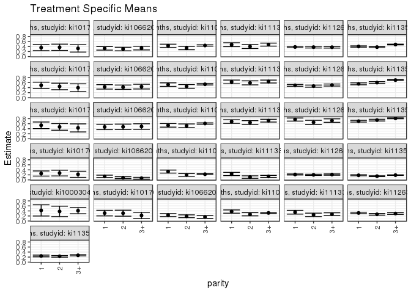

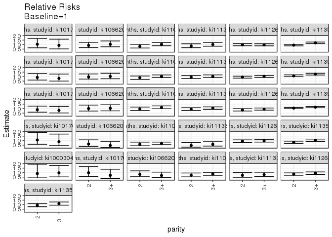

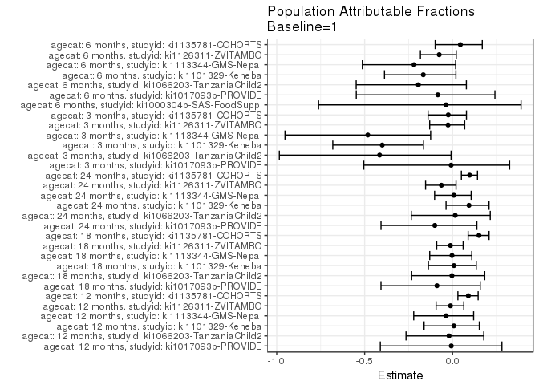

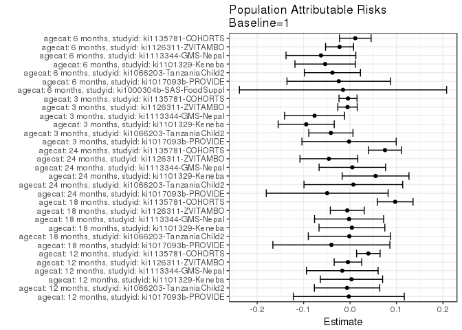

## Data Summary

| agecat | studyid | A | n | nA | nAY0 | nAY1 |
| --- | --- | --- | --- | --- | --- | --- |
| 3 months | ki1000304b-SAS-FoodSuppl | 1 | 0 | 0 | 0 | 0 |
| 3 months | ki1000304b-SAS-FoodSuppl | 2 | 0 | 0 | 0 | 0 |
| 3 months | ki1000304b-SAS-FoodSuppl | 3+ | 0 | 0 | 0 | 0 |
| 3 months | ki1017093b-PROVIDE | 1 | 175 | 71 | 53 | 18 |
| 3 months | ki1017093b-PROVIDE | 2 | 175 | 59 | 43 | 16 |
| 3 months | ki1017093b-PROVIDE | 3+ | 175 | 45 | 35 | 10 |
| 3 months | ki1066203-TanzaniaChild2 | 1 | 593 | 206 | 177 | 29 |
| 3 months | ki1066203-TanzaniaChild2 | 2 | 593 | 204 | 186 | 18 |
| 3 months | ki1066203-TanzaniaChild2 | 3+ | 593 | 183 | 171 | 12 |
| 3 months | ki1101329-Keneba | 1 | 1809 | 233 | 156 | 77 |
| 3 months | ki1101329-Keneba | 2 | 1809 | 197 | 158 | 39 |
| 3 months | ki1101329-Keneba | 3+ | 1809 | 1379 | 1068 | 311 |
| 3 months | ki1113344-GMS-Nepal | 1 | 593 | 166 | 127 | 39 |
| 3 months | ki1113344-GMS-Nepal | 2 | 593 | 153 | 136 | 17 |
| 3 months | ki1113344-GMS-Nepal | 3+ | 593 | 274 | 236 | 38 |
| 3 months | ki1126311-ZVITAMBO | 1 | 3502 | 1491 | 1170 | 321 |
| 3 months | ki1126311-ZVITAMBO | 2 | 3502 | 1023 | 818 | 205 |
| 3 months | ki1126311-ZVITAMBO | 3+ | 3502 | 988 | 779 | 209 |
| 3 months | ki1135781-COHORTS | 1 | 8043 | 1522 | 1244 | 278 |
| 3 months | ki1135781-COHORTS | 2 | 8043 | 1914 | 1631 | 283 |
| 3 months | ki1135781-COHORTS | 3+ | 8043 | 4607 | 3734 | 873 |
| 6 months | ki1000304b-SAS-FoodSuppl | 1 | 101 | 19 | 11 | 8 |
| 6 months | ki1000304b-SAS-FoodSuppl | 2 | 101 | 21 | 13 | 8 |
| 6 months | ki1000304b-SAS-FoodSuppl | 3+ | 101 | 61 | 36 | 25 |
| 6 months | ki1017093b-PROVIDE | 1 | 166 | 67 | 46 | 21 |
| 6 months | ki1017093b-PROVIDE | 2 | 166 | 58 | 40 | 18 |
| 6 months | ki1017093b-PROVIDE | 3+ | 166 | 41 | 32 | 9 |
| 6 months | ki1066203-TanzaniaChild2 | 1 | 549 | 189 | 145 | 44 |
| 6 months | ki1066203-TanzaniaChild2 | 2 | 549 | 191 | 155 | 36 |
| 6 months | ki1066203-TanzaniaChild2 | 3+ | 549 | 169 | 142 | 27 |

[output cut: 75 more lines]

## Results Table

### Parameter: TSM

| agecat | studyid | intervention_level | baseline_level | estimate | ci_lower | ci_upper |
| --- | --- | --- | --- | --- | --- | --- |
| 3 months | ki1017093b-PROVIDE | 1 | NA | 0.2535211 | 0.1520414 | 0.3550008 |
| 3 months | ki1017093b-PROVIDE | 2 | NA | 0.2711864 | 0.1574214 | 0.3849514 |
| 3 months | ki1017093b-PROVIDE | 3+ | NA | 0.2222222 | 0.1004053 | 0.3440392 |
| 3 months | ki1066203-TanzaniaChild2 | 1 | NA | 0.1407767 | 0.0932432 | 0.1883102 |
| 3 months | ki1066203-TanzaniaChild2 | 2 | NA | 0.0882353 | 0.0492804 | 0.1271902 |
| 3 months | ki1066203-TanzaniaChild2 | 3+ | NA | 0.0655738 | 0.0296794 | 0.1014682 |
| 3 months | ki1101329-Keneba | 1 | NA | 0.3304721 | 0.2700575 | 0.3908867 |
| 3 months | ki1101329-Keneba | 2 | NA | 0.1979695 | 0.1423113 | 0.2536278 |
| 3 months | ki1101329-Keneba | 3+ | NA | 0.2255257 | 0.2034616 | 0.2475899 |
| 3 months | ki1113344-GMS-Nepal | 1 | NA | 0.2349398 | 0.1703912 | 0.2994883 |
| 3 months | ki1113344-GMS-Nepal | 2 | NA | 0.1111111 | 0.0612719 | 0.1609503 |
| 3 months | ki1113344-GMS-Nepal | 3+ | NA | 0.1386861 | 0.0977283 | 0.1796439 |
| 3 months | ki1126311-ZVITAMBO | 1 | NA | 0.2152918 | 0.1944258 | 0.2361577 |
| 3 months | ki1126311-ZVITAMBO | 2 | NA | 0.2003910 | 0.1758580 | 0.2249240 |
| 3 months | ki1126311-ZVITAMBO | 3+ | NA | 0.2115385 | 0.1860692 | 0.2370077 |
| 3 months | ki1135781-COHORTS | 1 | NA | 0.1826544 | 0.1632417 | 0.2020671 |
| 3 months | ki1135781-COHORTS | 2 | NA | 0.1478579 | 0.1319548 | 0.1637610 |
| 3 months | ki1135781-COHORTS | 3+ | NA | 0.1894942 | 0.1781770 | 0.2008115 |
| 6 months | ki1000304b-SAS-FoodSuppl | 1 | NA | 0.4210526 | 0.1979423 | 0.6441630 |
| 6 months | ki1000304b-SAS-FoodSuppl | 2 | NA | 0.3809524 | 0.1722168 | 0.5896880 |
| 6 months | ki1000304b-SAS-FoodSuppl | 3+ | NA | 0.4098361 | 0.2858036 | 0.5338685 |
| 6 months | ki1017093b-PROVIDE | 1 | NA | 0.3134328 | 0.2020197 | 0.4248460 |
| 6 months | ki1017093b-PROVIDE | 2 | NA | 0.3103448 | 0.1909228 | 0.4297668 |
| 6 months | ki1017093b-PROVIDE | 3+ | NA | 0.2195122 | 0.0924312 | 0.3465932 |
| 6 months | ki1066203-TanzaniaChild2 | 1 | NA | 0.2328042 | 0.1724981 | 0.2931104 |
| 6 months | ki1066203-TanzaniaChild2 | 2 | NA | 0.1884817 | 0.1329666 | 0.2439968 |
| 6 months | ki1066203-TanzaniaChild2 | 3+ | NA | 0.1597633 | 0.1044742 | 0.2150525 |
| 6 months | ki1101329-Keneba | 1 | NA | 0.3755869 | 0.3105327 | 0.4406410 |
| 6 months | ki1101329-Keneba | 2 | NA | 0.2688172 | 0.2050850 | 0.3325494 |
| 6 months | ki1101329-Keneba | 3+ | NA | 0.3207831 | 0.2956709 | 0.3458953 |

[output cut: 63 more lines]

### Parameter: E(Y)

| agecat | studyid | intervention_level | baseline_level | estimate | ci_lower | ci_upper |
| --- | --- | --- | --- | --- | --- | --- |
| 3 months | ki1017093b-PROVIDE | NA | NA | 0.2514286 | 0.2486380 | 0.2542192 |
| 3 months | ki1066203-TanzaniaChild2 | NA | NA | 0.0994941 | 0.0969586 | 0.1020296 |
| 3 months | ki1101329-Keneba | NA | NA | 0.2360420 | 0.2343231 | 0.2377610 |
| 3 months | ki1113344-GMS-Nepal | NA | NA | 0.1585160 | 0.1545726 | 0.1624594 |
| 3 months | ki1126311-ZVITAMBO | NA | NA | 0.2098801 | 0.2096718 | 0.2100884 |
| 3 months | ki1135781-COHORTS | NA | NA | 0.1782917 | 0.1779157 | 0.1786676 |
| 6 months | ki1000304b-SAS-FoodSuppl | NA | NA | 0.4059406 | 0.4032968 | 0.4085844 |
| 6 months | ki1017093b-PROVIDE | NA | NA | 0.2891566 | 0.2830672 | 0.2952460 |
| 6 months | ki1066203-TanzaniaChild2 | NA | NA | 0.1948998 | 0.1924035 | 0.1973962 |
| 6 months | ki1101329-Keneba | NA | NA | 0.3219456 | 0.3207336 | 0.3231575 |
| 6 months | ki1113344-GMS-Nepal | NA | NA | 0.2857143 | 0.2823952 | 0.2890333 |
| 6 months | ki1126311-ZVITAMBO | NA | NA | 0.2965879 | 0.2956754 | 0.2975004 |
| 6 months | ki1135781-COHORTS | NA | NA | 0.2551748 | 0.2545398 | 0.2558097 |
| 12 months | ki1017093b-PROVIDE | NA | NA | 0.3522013 | 0.3495774 | 0.3548251 |
| 12 months | ki1066203-TanzaniaChild2 | NA | NA | 0.3210634 | 0.3196117 | 0.3225151 |
| 12 months | ki1101329-Keneba | NA | NA | 0.4289709 | 0.4275746 | 0.4303673 |
| 12 months | ki1113344-GMS-Nepal | NA | NA | 0.4553265 | 0.4526721 | 0.4579808 |
| 12 months | ki1126311-ZVITAMBO | NA | NA | 0.3770621 | 0.3769084 | 0.3772158 |
| 12 months | ki1135781-COHORTS | NA | NA | 0.4401408 | 0.4391068 | 0.4411748 |
| 18 months | ki1017093b-PROVIDE | NA | NA | 0.4516129 | 0.4456228 | 0.4576030 |
| 18 months | ki1066203-TanzaniaChild2 | NA | NA | 0.4281690 | 0.4272375 | 0.4291005 |
| 18 months | ki1101329-Keneba | NA | NA | 0.5224138 | 0.5212344 | 0.5235932 |
| 18 months | ki1113344-GMS-Nepal | NA | NA | 0.6236934 | 0.6219503 | 0.6254364 |
| 18 months | ki1126311-ZVITAMBO | NA | NA | 0.4857297 | 0.4849405 | 0.4865188 |
| 18 months | ki1135781-COHORTS | NA | NA | 0.6477457 | 0.6455044 | 0.6499870 |
| 24 months | ki1017093b-PROVIDE | NA | NA | 0.4864865 | 0.4797865 | 0.4931864 |
| 24 months | ki1066203-TanzaniaChild2 | NA | NA | 0.4777328 | 0.4768495 | 0.4786161 |
| 24 months | ki1101329-Keneba | NA | NA | 0.5901926 | 0.5886209 | 0.5917644 |
| 24 months | ki1113344-GMS-Nepal | NA | NA | 0.6901408 | 0.6876099 | 0.6926718 |
| 24 months | ki1126311-ZVITAMBO | NA | NA | 0.7197452 | 0.7156914 | 0.7237990 |
| 24 months | ki1135781-COHORTS | NA | NA | 0.7750329 | 0.7733042 | 0.7767617 |

### Parameter: RR

| agecat | studyid | intervention_level | baseline_level | estimate | ci_lower | ci_upper |
| --- | --- | --- | --- | --- | --- | --- |
| 3 months | ki1017093b-PROVIDE | 2 | 1 | 1.0696798 | 0.5990090 | 1.9101801 |
| 3 months | ki1017093b-PROVIDE | 3+ | 1 | 0.8765432 | 0.4446204 | 1.7280539 |
| 3 months | ki1066203-TanzaniaChild2 | 2 | 1 | 0.6267748 | 0.3595240 | 1.0926857 |
| 3 months | ki1066203-TanzaniaChild2 | 3+ | 1 | 0.4657999 | 0.2448399 | 0.8861689 |
| 3 months | ki1101329-Keneba | 2 | 1 | 0.5990507 | 0.4283714 | 0.8377351 |
| 3 months | ki1101329-Keneba | 3+ | 1 | 0.6824350 | 0.5546414 | 0.8396733 |
| 3 months | ki1113344-GMS-Nepal | 2 | 1 | 0.4729345 | 0.2794850 | 0.8002828 |
| 3 months | ki1113344-GMS-Nepal | 3+ | 1 | 0.5903051 | 0.3943642 | 0.8835998 |
| 3 months | ki1126311-ZVITAMBO | 2 | 1 | 0.9307881 | 0.7962285 | 1.0880879 |
| 3 months | ki1126311-ZVITAMBO | 3+ | 1 | 0.9825665 | 0.8418529 | 1.1468000 |
| 3 months | ki1135781-COHORTS | 2 | 1 | 0.8094954 | 0.6958974 | 0.9416370 |
| 3 months | ki1135781-COHORTS | 3+ | 1 | 1.0374469 | 0.9183752 | 1.1719569 |
| 6 months | ki1000304b-SAS-FoodSuppl | 2 | 1 | 0.9047619 | 0.4221804 | 1.9389678 |
| 6 months | ki1000304b-SAS-FoodSuppl | 3+ | 1 | 0.9733607 | 0.5287590 | 1.7918011 |
| 6 months | ki1017093b-PROVIDE | 2 | 1 | 0.9901478 | 0.5863967 | 1.6718932 |
| 6 months | ki1017093b-PROVIDE | 3+ | 1 | 0.7003484 | 0.3550418 | 1.3814935 |
| 6 months | ki1066203-TanzaniaChild2 | 2 | 1 | 0.8096145 | 0.5469261 | 1.1984720 |
| 6 months | ki1066203-TanzaniaChild2 | 3+ | 1 | 0.6862561 | 0.4453987 | 1.0573613 |
| 6 months | ki1101329-Keneba | 2 | 1 | 0.7157258 | 0.5336194 | 0.9599790 |
| 6 months | ki1101329-Keneba | 3+ | 1 | 0.8540851 | 0.7062396 | 1.0328808 |
| 6 months | ki1113344-GMS-Nepal | 2 | 1 | 0.6981982 | 0.4886610 | 0.9975846 |
| 6 months | ki1113344-GMS-Nepal | 3+ | 1 | 0.7828283 | 0.5845479 | 1.0483660 |
| 6 months | ki1126311-ZVITAMBO | 2 | 1 | 0.8315134 | 0.7109726 | 0.9724912 |
| 6 months | ki1126311-ZVITAMBO | 3+ | 1 | 0.9317108 | 0.8028255 | 1.0812873 |
| 6 months | ki1135781-COHORTS | 2 | 1 | 0.9372963 | 0.7693189 | 1.1419507 |
| 6 months | ki1135781-COHORTS | 3+ | 1 | 1.1067640 | 0.9427633 | 1.2992939 |
| 12 months | ki1017093b-PROVIDE | 2 | 1 | 1.0382775 | 0.6429851 | 1.6765865 |
| 12 months | ki1017093b-PROVIDE | 3+ | 1 | 0.9159091 | 0.5229475 | 1.6041561 |
| 12 months | ki1066203-TanzaniaChild2 | 2 | 1 | 0.9123476 | 0.6636289 | 1.2542825 |
| 12 months | ki1066203-TanzaniaChild2 | 3+ | 1 | 1.0310761 | 0.7572705 | 1.4038813 |
| 12 months | ki1101329-Keneba | 2 | 1 | 0.7999753 | 0.6191312 | 1.0336428 |
| 12 months | ki1101329-Keneba | 3+ | 1 | 1.0354773 | 0.8751874 | 1.2251242 |
| 12 months | ki1113344-GMS-Nepal | 2 | 1 | 0.8473684 | 0.6563990 | 1.0938975 |
| 12 months | ki1113344-GMS-Nepal | 3+ | 1 | 1.0083997 | 0.8208166 | 1.2388515 |
| 12 months | ki1126311-ZVITAMBO | 2 | 1 | 0.9849998 | 0.8731685 | 1.1111539 |
| 12 months | ki1126311-ZVITAMBO | 3+ | 1 | 0.9755252 | 0.8647011 | 1.1005529 |
| 12 months | ki1135781-COHORTS | 2 | 1 | 0.9389776 | 0.8610342 | 1.0239766 |
| 12 months | ki1135781-COHORTS | 3+ | 1 | 1.1958641 | 1.1147327 | 1.2829003 |
| 18 months | ki1017093b-PROVIDE | 2 | 1 | 0.9077381 | 0.6153724 | 1.3390078 |
| 18 months | ki1017093b-PROVIDE | 3+ | 1 | 0.8026316 | 0.5013218 | 1.2850379 |
| 18 months | ki1066203-TanzaniaChild2 | 2 | 1 | 0.9710781 | 0.7260002 | 1.2988877 |
| 18 months | ki1066203-TanzaniaChild2 | 3+ | 1 | 1.0221064 | 0.7594729 | 1.3755613 |
| 18 months | ki1101329-Keneba | 2 | 1 | 0.8648555 | 0.6980884 | 1.0714616 |
| 18 months | ki1101329-Keneba | 3+ | 1 | 1.0270854 | 0.8880495 | 1.1878892 |
| 18 months | ki1113344-GMS-Nepal | 2 | 1 | 0.9413108 | 0.7860142 | 1.1272900 |
| 18 months | ki1113344-GMS-Nepal | 3+ | 1 | 1.0251572 | 0.8831472 | 1.1900025 |
| 18 months | ki1126311-ZVITAMBO | 2 | 1 | 0.9352524 | 0.8317993 | 1.0515722 |
| 18 months | ki1126311-ZVITAMBO | 3+ | 1 | 1.0220985 | 0.9161125 | 1.1403462 |
| 18 months | ki1135781-COHORTS | 2 | 1 | 1.0881169 | 0.9900383 | 1.1959117 |
| 18 months | ki1135781-COHORTS | 3+ | 1 | 1.2706634 | 1.1775343 | 1.3711580 |
| 24 months | ki1017093b-PROVIDE | 2 | 1 | 0.8824242 | 0.6083804 | 1.2799107 |
| 24 months | ki1017093b-PROVIDE | 3+ | 1 | 0.8072072 | 0.5178454 | 1.2582588 |
| 24 months | ki1066203-TanzaniaChild2 | 2 | 1 | 1.0106707 | 0.7333121 | 1.3929339 |
| 24 months | ki1066203-TanzaniaChild2 | 3+ | 1 | 1.0359375 | 0.7530278 | 1.4251353 |
| 24 months | ki1101329-Keneba | 2 | 1 | 0.9623178 | 0.7884189 | 1.1745730 |
| 24 months | ki1101329-Keneba | 3+ | 1 | 1.1341186 | 0.9849813 | 1.3058369 |
| 24 months | ki1113344-GMS-Nepal | 2 | 1 | 0.9396520 | 0.8009813 | 1.1023301 |
| 24 months | ki1113344-GMS-Nepal | 3+ | 1 | 1.0496881 | 0.9224658 | 1.1944564 |
| 24 months | ki1126311-ZVITAMBO | 2 | 1 | 0.8546732 | 0.7371136 | 0.9909819 |
| 24 months | ki1126311-ZVITAMBO | 3+ | 1 | 0.9450030 | 0.8331924 | 1.0718180 |
| 24 months | ki1135781-COHORTS | 2 | 1 | 1.0595012 | 0.9897552 | 1.1341620 |
| 24 months | ki1135781-COHORTS | 3+ | 1 | 1.1647039 | 1.1020046 | 1.2309706 |

### Parameter: PAR

| agecat | studyid | intervention_level | baseline_level | estimate | ci_lower | ci_upper |
| --- | --- | --- | --- | --- | --- | --- |
| 3 months | ki1017093b-PROVIDE | 1 | NA | -0.0020926 | -0.1036106 | 0.0994255 |
| 3 months | ki1066203-TanzaniaChild2 | 1 | NA | -0.0412826 | -0.0888836 | 0.0063184 |
| 3 months | ki1101329-Keneba | 1 | NA | -0.0944301 | -0.1548691 | -0.0339910 |
| 3 months | ki1113344-GMS-Nepal | 1 | NA | -0.0764237 | -0.1410927 | -0.0117548 |
| 3 months | ki1126311-ZVITAMBO | 1 | NA | -0.0054117 | -0.0262787 | 0.0154554 |
| 3 months | ki1135781-COHORTS | 1 | NA | -0.0043627 | -0.0237790 | 0.0150536 |
| 6 months | ki1000304b-SAS-FoodSuppl | 1 | NA | -0.0151120 | -0.2382380 | 0.2080140 |
| 6 months | ki1017093b-PROVIDE | 1 | NA | -0.0242762 | -0.1358557 | 0.0873032 |
| 6 months | ki1066203-TanzaniaChild2 | 1 | NA | -0.0379044 | -0.0982622 | 0.0224534 |
| 6 months | ki1101329-Keneba | 1 | NA | -0.0536413 | -0.1187068 | 0.0114242 |
| 6 months | ki1113344-GMS-Nepal | 1 | NA | -0.0626728 | -0.1378205 | 0.0124748 |
| 6 months | ki1126311-ZVITAMBO | 1 | NA | -0.0225842 | -0.0527595 | 0.0075911 |
| 6 months | ki1135781-COHORTS | 1 | NA | 0.0113122 | -0.0227482 | 0.0453726 |
| 12 months | ki1017093b-PROVIDE | 1 | NA | -0.0026375 | -0.1221398 | 0.1168649 |
| 12 months | ki1066203-TanzaniaChild2 | 1 | NA | -0.0064220 | -0.0768481 | 0.0640041 |
| 12 months | ki1101329-Keneba | 1 | NA | 0.0031336 | -0.0639367 | 0.0702038 |
| 12 months | ki1113344-GMS-Nepal | 1 | NA | -0.0167232 | -0.0939478 | 0.0605014 |
| 12 months | ki1126311-ZVITAMBO | 1 | NA | -0.0044913 | -0.0341635 | 0.0251808 |
| 12 months | ki1135781-COHORTS | 1 | NA | 0.0394464 | 0.0141133 | 0.0647795 |
| 18 months | ki1017093b-PROVIDE | 1 | NA | -0.0401904 | -0.1661965 | 0.0858157 |
| 18 months | ki1066203-TanzaniaChild2 | 1 | NA | -0.0015831 | -0.0899181 | 0.0867520 |
| 18 months | ki1101329-Keneba | 1 | NA | 0.0040892 | -0.0668024 | 0.0749807 |
| 18 months | ki1113344-GMS-Nepal | 1 | NA | -0.0020735 | -0.0764489 | 0.0723020 |
| 18 months | ki1126311-ZVITAMBO | 1 | NA | -0.0059601 | -0.0424446 | 0.0305244 |
| 18 months | ki1135781-COHORTS | 1 | NA | 0.0972014 | 0.0586811 | 0.1357216 |
| 24 months | ki1017093b-PROVIDE | 1 | NA | -0.0492278 | -0.1804636 | 0.0820080 |
| 24 months | ki1066203-TanzaniaChild2 | 1 | NA | 0.0071446 | -0.0991845 | 0.1134736 |
| 24 months | ki1101329-Keneba | 1 | NA | 0.0550575 | -0.0168523 | 0.1269673 |
| 24 months | ki1113344-GMS-Nepal | 1 | NA | 0.0049557 | -0.0666712 | 0.0765825 |
| 24 months | ki1126311-ZVITAMBO | 1 | NA | -0.0456179 | -0.1078962 | 0.0166604 |
| 24 months | ki1135781-COHORTS | 1 | NA | 0.0751885 | 0.0397149 | 0.1106620 |

### Parameter: PAF

| agecat | studyid | intervention_level | baseline_level | estimate | ci_lower | ci_upper |
| --- | --- | --- | --- | --- | --- | --- |
| 3 months | ki1017093b-PROVIDE | 1 | NA | -0.0083227 | -0.5048949 | 0.3243950 |
| 3 months | ki1066203-TanzaniaChild2 | 1 | NA | -0.4149251 | -0.9851379 | -0.0085008 |
| 3 months | ki1101329-Keneba | 1 | NA | -0.4000563 | -0.6811372 | -0.1659712 |
| 3 months | ki1113344-GMS-Nepal | 1 | NA | -0.4821200 | -0.9529531 | -0.1247990 |
| 3 months | ki1126311-ZVITAMBO | 1 | NA | -0.0257846 | -0.1301863 | 0.0689729 |
| 3 months | ki1135781-COHORTS | 1 | NA | -0.0244696 | -0.1393716 | 0.0788450 |
| 6 months | ki1000304b-SAS-FoodSuppl | 1 | NA | -0.0372272 | -0.7620504 | 0.3894384 |
| 6 months | ki1017093b-PROVIDE | 1 | NA | -0.0839552 | -0.5475932 | 0.2407831 |
| 6 months | ki1066203-TanzaniaChild2 | 1 | NA | -0.1944815 | -0.5481660 | 0.0784024 |
| 6 months | ki1101329-Keneba | 1 | NA | -0.1666160 | -0.3872938 | 0.0189584 |
| 6 months | ki1113344-GMS-Nepal | 1 | NA | -0.2193548 | -0.5130476 | 0.0173302 |
| 6 months | ki1126311-ZVITAMBO | 1 | NA | -0.0761467 | -0.1828609 | 0.0209401 |
| 6 months | ki1135781-COHORTS | 1 | NA | 0.0443313 | -0.0989161 | 0.1689060 |
| 12 months | ki1017093b-PROVIDE | 1 | NA | -0.0074885 | -0.4109190 | 0.2805873 |
| 12 months | ki1066203-TanzaniaChild2 | 1 | NA | -0.0200022 | -0.2647289 | 0.1773695 |
| 12 months | ki1101329-Keneba | 1 | NA | 0.0073049 | -0.1620316 | 0.1519649 |
| 12 months | ki1113344-GMS-Nepal | 1 | NA | -0.0367280 | -0.2210010 | 0.1197346 |
| 12 months | ki1126311-ZVITAMBO | 1 | NA | -0.0119114 | -0.0937453 | 0.0637996 |
| 12 months | ki1135781-COHORTS | 1 | NA | 0.0896222 | 0.0302158 | 0.1453896 |
| 18 months | ki1017093b-PROVIDE | 1 | NA | -0.0889930 | -0.4070842 | 0.1571892 |
| 18 months | ki1066203-TanzaniaChild2 | 1 | NA | -0.0036973 | -0.2327400 | 0.1827894 |
| 18 months | ki1101329-Keneba | 1 | NA | 0.0078275 | -0.1375900 | 0.1346563 |
| 18 months | ki1113344-GMS-Nepal | 1 | NA | -0.0033245 | -0.1299508 | 0.1091116 |
| 18 months | ki1126311-ZVITAMBO | 1 | NA | -0.0122704 | -0.0902405 | 0.0601237 |
| 18 months | ki1135781-COHORTS | 1 | NA | 0.1500610 | 0.0884930 | 0.2074704 |
| 24 months | ki1017093b-PROVIDE | 1 | NA | -0.1011905 | -0.4069626 | 0.1381288 |
| 24 months | ki1066203-TanzaniaChild2 | 1 | NA | 0.0149551 | -0.2347653 | 0.2141718 |
| 24 months | ki1101329-Keneba | 1 | NA | 0.0932874 | -0.0371136 | 0.2072924 |
| 24 months | ki1113344-GMS-Nepal | 1 | NA | 0.0071807 | -0.1022230 | 0.1057252 |
| 24 months | ki1126311-ZVITAMBO | 1 | NA | -0.0633806 | -0.1535528 | 0.0197429 |
| 24 months | ki1135781-COHORTS | 1 | NA | 0.0970132 | 0.0500736 | 0.1416334 |